# Stats 20, S22A – Homework 1

Jun Ryu – 605574052

08/10/22

## Question 1

### (a)

“**Sometimes you have to make the hardest climb to see the most beautiful sunrise.** I read that once on an old lady’s decorative pillow, but it is really how I feel today. I’ve climbed a very weird and rocky mountain, and it was a pain in the ass, and my legs are tired, and I’m starving. But *the sun is rising over a sea of love and waffles and possibility. So I’m just gonna relax and take a deep breath and enjoy this view for as long as I possibly can.*” - Leslie Knope (from *Parks and Recreation*)

### (b)

| Homework | Midterm | Final Exam | Final Project |
| --- | --- | --- | --- |
| 18% | 30% | 40% | 12% |

### (c)

- 2020-21
  - Fall
    - Cluster 60A
    - Asian Am 20
    - PIC 10A
  - Winter
    - Cluster 60B
    - Math 33A
    - Math 33B
    - Physics 1A
  - Spring
    - Cluster 60CW
    - Math 61
    - Math 115A
    - Astr 5
- 2021-22
  - Fall
    - PIC 10B
    - Physics 1B
    - Math 131AH
  - Winter
    - Math 151A
    - Physics 1C
    - Math 192
    - PIC 16A
  - Spring
    - Math 116
    - Math 115B
    - Math 151BH
    - Math 192

### (d)

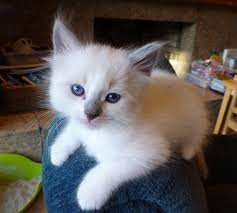

Sample kitten from: https://en.wikipedia.org/wiki/Kitten#/media/File:Juvenile_Ragdoll.jpg

## Question 2

### (a)

These videos are relevant to this course because in a coding-based environment, ambiguous directions to formulate a piece of code/algorithm can result in misinterpretations, leading to a completely different execution of the original idea. Moreover, when presenting a piece of code to others, it is important to adequately explain the piece of code and what each chunk performs so that it’s easy for the reader to digest.

### (b)

#### How to Make a Grilled Cheese Sandwich

1. Prepare the ingredients: Two tablespoons of butter, Two slices of white bread, roughly two ounces of American cheese, a butter knife, steel turner, and a nonstick pan
2. Put a nonstick pan on the stove over medium heat
3. Using a butter knife, put only a tablespoon of butter in the pan
4. Have the butter melt completely and evenly coat the surface of the pan
5. Take one slice of bread and lay it on top of the melted butter
6. Immediately drop the two ounces of American cheese on top of the slice that is on the pan
7. Put the second piece of bread on top of the cheese
8. Using a butter knife, spread the other tablespoon of butter on the top surface of the second piece of bread (the bread on the top)
9. Wait about 3 minutes
10. Flip the sandwich using a steel turner
11. Wait about 3 more minutes
12. Turn off the heat, and plate the grilled cheese sandwich

Note: I did not use any outside sources.

## Question 3

### (a)

```r
(6^8)/(16^5)
```

```
## [1] 1.601807
```

```r
101^(-7/8)
```

```
## [1] 0.01762864
```

```r
8+(3*pi)-3+(4/2*(-1))
```

```
## [1] 12.42478
```

1. 1.601807
2. 0.01762864
3. 12.42478

### (b)

```r
log(54, base=3)
```

```
## [1] 3.63093
```

```r
exp(exp(sqrt(2)))
```

```
## [1] 61.14514
```

```r
(exp(pi)+exp(-pi))/2
```

```
## [1] 11.59195
```

1. 3.63093
2. 61.14514
3. 11.59195

### (c)

```r
119%/%25
```

```
## [1] 4
```

```r
119%%25
```

```
## [1] 19
```

1. 4
2. 19

## Question 4

### (a)

```r
vol_1 <- (4/3)*pi*(1^3)
vol_4 <- (4/3)*pi*(4^3)
vol_1
```

```
## [1] 4.18879
```

```r
vol_4
```

```
## [1] 268.0826
```

1. 4.18879
2. 268.0826

### (b)

```r
vol_sphere <- function(r=1) {
  (4/3)*pi*(r^3)
}
```

### (c)

```r
vol_sphere()
```

```
## [1] 4.18879
```

```r
vol_sphere(4)
```

```
## [1] 268.0826
```

1. 4.18879
2. 268.0826

## Question 5

### (a)

```r
z_prop <- function(x,n,p0) {
  p_hat <- x/n
  (p_hat-p0)/(sqrt(p0*(1-p0)/n))
}
```

### (b)

```r
z_prop(10,13,.6)
```

```
## [1] 1.245505
```

### (d)

```r
z_prop(30,39,.6)
```

```
## [1] 2.157277
```

We notice that the z-statistic value has gone up. We notice this change because even though this sample gives the same proportion of people who preferred waffles as the one above (roughly 77%), given that we have a larger sample size, the denominator in the formula will have a smaller value, making our total z-value go up.

## Question 6

### (a)

```r
lease_calc <- function(msrp, price, down, n=36, res=0.60, mf=0.001, tax=0.095) {
  capitalized_cost <- (price-down)
  residual_value <- (msrp*res)
  monthly_depreciation <- (capitalized_cost-residual_value)/n
  monthly_finance_charge <- (capitalized_cost+residual_value)*mf
  sub_total <- monthly_depreciation+monthly_finance_charge
  total <- sub_total*(1+tax)
  total
}
```

### (b)

```r
lease_calc(31495,29895,2500, ,0.52,0.0016, )
```

```
## [1] 411.8079
```

## Question 7

### (a)

We would need 5 coins. Essentially, we want to minimize the number of coins used by trying to exhaust the original value with the largest coin value (quarters) as much as possible and moving on to the second largest coin value (dimes), and so forth.

### (b)

We will utilize the remainder function. We first calculate the number of quarters used by seeing how much 25 goes into our original value. Then, we take the remainder of the original value when divided by 25 because that gives us the remaining value after the original value has been exhausted with quarters. We take this remainder and run it through the same process but with dimes, the next largest coin value. Then, we repeat the process for nickels and pennies.

### (c)

```r
get_minimum_coins <- function(cents) {
  quarters <- (cents%/%25)
  dimes <- (cents%%25)%/%10
  nickels <- ((cents%%25)%%10)%/%5
  pennies <- (((cents%%25)%%10)%%5)
  quarters + dimes + nickels + pennies
}
```

### (d)

```r
get_minimum_coins(31)
```

```
## [1] 3
```

```r
get_minimum_coins(48)
```

```
## [1] 6
```

```r
get_minimum_coins(139)
```

```
## [1] 10
```

1. 3 coins
2. 6 coins
3. 10 coins

### (e)

```r
get_minimum_coins(99)
```

```
## [1] 9
```

```r
get_minimum_coins(94)
```

```
## [1] 9
```

We approach this problem by trying to use as many coins as possible starting with quarters without hitting 100. We observe that we can use 3 quarters without hitting 100, giving us a spare 24 cents to work with. Now, we repeat the process but with dimes, giving us a total of 2 dimes used, and leaving us with 4 cents. Now, we exhaust these 4 cents with 4 pennies, giving us a grand total of 9 coins used. We know this is the maximum because we have fully reached 99 cents using the idea of minimizing the number of coins used. However, we also notice that 94 cents also attains the same value of 9 coins used (3 quarters, 1 dime, 1 nickel, 4 pennies), so 94 is also included in our answer.

## Question 8

```r
x <- 3
y <- 4
exp1 <- function() {
  x^y
}
exp2 <- function(x = 2) {
  x^y
}
exp_y <- function(x) {
  function(y) {
    x^y
  }
}
```

### (a)

The function exp1 deal with global variables defined above the function and exp2 deals with local variables since x is specified in the function argument. Thus, exp1 will return 3^4 (or 81), whereas exp2 will return 2^4 (or 16).

### (b)

We have a nested function situation where there exists a function inside a function, meaning that running exp_y() will return the inner function, rather than a numeric value. This does not throw an error because functions can live inside other functions; they just need to be called properly in order for inner functions to run.

### (c)

```r
exp_y(11)(4)
```

```
## [1] 14641
```